# Phenology project

Pat Dumandan

**I. Data Preparation**

**Notes:**  
* use Sarah’s code to check for bad tags, bad periods and remove them (manually double checked the data on reproductive indivs.as well. Also, with the use of Sarah’s code, I have fewer observations now)  
* use only data from 1988-2014 (period when the plot assignments were fairly constant)  
* use only plot-level data from 18 plots (control and exclosure): 1, 2, 4, 8, 9, 11, 12, 14, 17, 22,3, 6, 13, 15, 18, 19, 20, 21  
* proportion of breeders is the number of individuals of a given species and sex in a given plot that exhibits reproductive characteristics divided by the total number of individuals of a given species and sex in a given plot  
* for months when no observations on reproductive individuals were made, set at 0 (not really account for detection bias)  
* lag of 1 set for abiotic covariates  
* all variables except month and year were standardized (centered each value on the mean and divided by two SDs, Gelman 2008). Not really sure how important it is to standardize variables that are treated as smooth terms since I’m not really interested in their effects. I’m just trying to capture the variation they are contributing.

```
##   year month meantemp   mintemp  maxtemp precipitation warm_precip cool_precip
## 1 1988     1 2.983871 0.4741935 14.37742        22.352    280.1866    52.61568
## 2 1988     1 2.983871 0.4741935 14.37742        22.352    280.1866    52.61568
## 3 1988     1 2.983871 0.4741935 14.37742        22.352    280.1866    52.61568
## 4 1988     1 2.983871 0.4741935 14.37742        22.352    280.1866    52.61568
## 5 1988     2 8.065517 2.7379310 15.55517        33.274    286.7134    71.39152
## 6 1988     2 8.065517 2.7379310 15.55517        33.274    286.7134    71.39152
##         date lag_temp_mean lag_temp_min lag_temp_max lag_ppt lag_ppt_warm
## 1 1988-01-01      2.703226    3.1322581     14.57097  49.530     257.5150
## 2 1988-01-01      2.703226    3.1322581     14.57097  49.530     257.5150
## 3 1988-01-01      2.703226    3.1322581     14.57097  49.530     257.5150
## 4 1988-01-01      2.703226    3.1322581     14.57097  49.530     257.5150
## 5 1988-02-01      2.983871    0.4741935     14.37742  22.352     280.1866
## 6 1988-02-01      2.983871    0.4741935     14.37742  22.352     280.1866
##   lag_ppt_cool      ndvi  lag_ndvi treatment reproductive abundance proportion
```

[output cut: 34 more lines]

**II. Analyses**  
*Goal*: Reconstruct breeding phenology of male and female PBs, PPs, and DMs in different biotic contexts (control vs k-rat exclosure) and determine the association between breeding odds and abiotic (e.g., NDVI, precipitation, warm_precip, cool_precip, and lags) and biotic (i.e., biomass of PB, PP, and all k-rats(DO,DM,DS)) factors.

A. Determining which abiotic variables to include in the models and what are the appropriate lags to apply  
*Partial list that Pat thinks should be in the model*

- lag of NDVI (proxy for primary productivity of the system leading to breeding event)
- lag of mean temperature (potential effect on physiological process–reduced energetic demands for homeothermy at higher temperatures)
- lag of warm and/or cool precipitation (proxy for primary productivity and also physiological effects for smaller species that may also be inactive during winter)  
  *Note: my concern here is that if I add all these, some may be collinear and would be harder to disentangle which one is the most likely driver*

*Other alternate variables that maybe important*

- lag of total precipitation (lag of this should be >1 than the lag for NDVI for it to make biological sense in the context of primary productivity)
- min and max temperature (also with lag of 1; if too low or too high, too early or late for breeding)
- lag of precipitation but data truncated to when there are no “flooding events” (i.e., when monthly precip > 35 cm or >than average precipitation)

**Results (exploratory work on abiotic factor effects)**  
In these explorations, I applied GAM approach and assumed linear relationships between the response variable and the abiotic variable

1. PB males (w/ lag of NDVI, mean temperature, warm and cool precip)

```r
pbcon_m=mgcv::gam(proportion~s(month, bs="cc")+s(year)+ndvis_lag+ temps_lag_mean+ppts_lag_warm+ppts_lag_cool,
              data=PB_male_con, weights=abundance, family=binomial(link="logit"))
pbex_m=mgcv::gam(proportion~s(month, bs="cc")+s(year)+ndvis_lag+ temps_lag_mean+ppts_lag_warm+ppts_lag_cool,
              data=PB_male_ex, weights=abundance, family=binomial(link="logit"))
```

1. control

```
##
## Family: binomial
## Link function: logit
##
## Formula:
## proportion ~ s(month, bs = "cc") + s(year) + ndvis_lag + temps_lag_mean +
##     ppts_lag_warm + ppts_lag_cool
##
## Parametric coefficients:
##                Estimate Std. Error z value Pr(>|z|)
## (Intercept)     -2.3733     0.1260 -18.841   <2e-16 ***
## ndvis_lag       -0.0216     0.1132  -0.191   0.8487
## temps_lag_mean  -0.8709     0.3413  -2.552   0.0107 *
## ppts_lag_warm    0.3372     0.1600   2.108   0.0351 *
## ppts_lag_cool   -0.6467     0.3183  -2.032   0.0422 *
## ---
## Signif. codes:  0 '***' 0.001 '**' 0.01 '*' 0.05 '.' 0.1 ' ' 1
##
## Approximate significance of smooth terms:
##             edf Ref.df Chi.sq p-value
## s(month) 0.9309      8  1.593   0.155
## s(year)  1.0002      1  0.136   0.713
##
## R-sq.(adj) =  0.145   Deviance explained = 16.5%
## UBRE = 0.16277  Scale est. = 1         n = 151
```

2. exclosure

```
##
## Family: binomial
## Link function: logit
##
## Formula:
## proportion ~ s(month, bs = "cc") + s(year) + ndvis_lag + temps_lag_mean +
##     ppts_lag_warm + ppts_lag_cool
##
## Parametric coefficients:
##                Estimate Std. Error z value Pr(>|z|)
## (Intercept)     -2.5469     0.1590 -16.019  < 2e-16 ***
## ndvis_lag        0.2729     0.0841   3.245  0.00118 **
## temps_lag_mean  -0.5186     0.4544  -1.141  0.25372
## ppts_lag_warm   -0.1126     0.1690  -0.666  0.50529
## ppts_lag_cool   -0.6899     0.2753  -2.506  0.01221 *
## ---
## Signif. codes:  0 '***' 0.001 '**' 0.01 '*' 0.05 '.' 0.1 ' ' 1
##
## Approximate significance of smooth terms:
##            edf Ref.df Chi.sq  p-value
## s(month) 2.474  8.000  32.35 6.28e-10 ***
## s(year)  4.366  5.342  25.37 0.000154 ***
## ---
## Signif. codes:  0 '***' 0.001 '**' 0.01 '*' 0.05 '.' 0.1 ' ' 1
##
## R-sq.(adj) =  0.351   Deviance explained = 34.8%
## UBRE = 0.20658  Scale est. = 1         n = 161
```

2. PB females (w/ lag of NDVI, mean temperature, warm and cool precip)

```r
pbcon_f=mgcv::gam(proportion~s(month, bs="cc")+s(year)+ndvis_lag+ temps_lag_mean+ppts_lag_warm+ppts_lag_cool,
              data=PB_female_con, weights=abundance, family=binomial(link="logit"))
pbex_f=mgcv::gam(proportion~s(month, bs="cc")+s(year)+ndvis_lag+ temps_lag_mean+ppts_lag_warm+ppts_lag_cool,
              data=PB_female_ex, weights=abundance, family=binomial(link="logit"))
```

1. control

```
##
## Family: binomial
## Link function: logit
##
## Formula:
## proportion ~ s(month, bs = "cc") + s(year) + ndvis_lag + temps_lag_mean +
##     ppts_lag_warm + ppts_lag_cool
##
## Parametric coefficients:
##                Estimate Std. Error z value Pr(>|z|)
## (Intercept)     -3.5222     0.4043  -8.712  < 2e-16 ***
## ndvis_lag        0.5152     0.1584   3.252  0.00115 **
## temps_lag_mean   2.6878     1.1892   2.260  0.02382 *
## ppts_lag_warm    0.8901     0.2963   3.004  0.00266 **
## ppts_lag_cool   -0.7732     0.4799  -1.611  0.10714
## ---
## Signif. codes:  0 '***' 0.001 '**' 0.01 '*' 0.05 '.' 0.1 ' ' 1
##
## Approximate significance of smooth terms:
##            edf Ref.df Chi.sq  p-value
## s(month) 4.512  8.000  76.85  < 2e-16 ***
## s(year)  6.742  7.595  27.29 0.000427 ***
## ---
## Signif. codes:  0 '***' 0.001 '**' 0.01 '*' 0.05 '.' 0.1 ' ' 1
##
## R-sq.(adj) =  0.535   Deviance explained = 61.4%
## UBRE = -0.029853  Scale est. = 1         n = 133
```

2. exclosure

```
##
## Family: binomial
## Link function: logit
##
## Formula:
## proportion ~ s(month, bs = "cc") + s(year) + ndvis_lag + temps_lag_mean +
##     ppts_lag_warm + ppts_lag_cool
##
## Parametric coefficients:
##                Estimate Std. Error z value Pr(>|z|)
## (Intercept)     -3.2790     0.2350 -13.952  < 2e-16 ***
## ndvis_lag        0.5128     0.1048   4.895 9.85e-07 ***
## temps_lag_mean  -1.3323     0.7889  -1.689  0.09124 .
## ppts_lag_warm    0.4592     0.1929   2.381  0.01729 *
## ppts_lag_cool   -0.9305     0.2887  -3.224  0.00127 **
## ---
## Signif. codes:  0 '***' 0.001 '**' 0.01 '*' 0.05 '.' 0.1 ' ' 1
##
## Approximate significance of smooth terms:
##            edf Ref.df Chi.sq  p-value
## s(month) 6.403  8.000 158.84  < 2e-16 ***
## s(year)  8.906  8.993  66.59 1.01e-10 ***
## ---
## Signif. codes:  0 '***' 0.001 '**' 0.01 '*' 0.05 '.' 0.1 ' ' 1
##
## R-sq.(adj) =  0.589   Deviance explained = 61.6%
## UBRE = 0.5613  Scale est. = 1         n = 149
```

3. PP males (w/ lag of NDVI, mean temperature, warm and cool precip)

```r
ppcon_m=mgcv::gam(proportion~s(month, bs="cc")+s(year)+ndvis_lag+ temps_lag_mean+ppts_lag_warm+ppts_lag_cool,
              data=PP_male_con, weights=abundance, family=binomial(link="logit"))
ppex_m=mgcv::gam(proportion~s(month, bs="cc")+s(year)+ndvis_lag+ temps_lag_mean+ppts_lag_warm+ppts_lag_cool,
              data=PP_male_ex, weights=abundance, family=binomial(link="logit"))
```

1. control

```
##
## Family: binomial
## Link function: logit
##
## Formula:
## proportion ~ s(month, bs = "cc") + s(year) + ndvis_lag + temps_lag_mean +
##     ppts_lag_warm + ppts_lag_cool
##
## Parametric coefficients:
##                Estimate Std. Error z value Pr(>|z|)
## (Intercept)     -2.5443     0.1605 -15.857  < 2e-16 ***
## ndvis_lag        0.3093     0.1056   2.929  0.00341 **
## temps_lag_mean  -1.8139     0.6717  -2.700  0.00693 **
## ppts_lag_warm    0.1025     0.1348   0.760  0.44697
## ppts_lag_cool   -0.9278     0.2085  -4.450 8.58e-06 ***
## ---
## Signif. codes:  0 '***' 0.001 '**' 0.01 '*' 0.05 '.' 0.1 ' ' 1
##
## Approximate significance of smooth terms:
##            edf Ref.df Chi.sq p-value
## s(month) 4.343      8 94.627  <2e-16 ***
## s(year)  1.000      1  0.296   0.586
## ---
## Signif. codes:  0 '***' 0.001 '**' 0.01 '*' 0.05 '.' 0.1 ' ' 1
##
## R-sq.(adj) =  0.608   Deviance explained = 62.5%
## UBRE = 0.045099  Scale est. = 1         n = 169
```

2. exclosure

```
##
## Family: binomial
## Link function: logit
##
## Formula:
## proportion ~ s(month, bs = "cc") + s(year) + ndvis_lag + temps_lag_mean +
##     ppts_lag_warm + ppts_lag_cool
##
## Parametric coefficients:
##                Estimate Std. Error z value Pr(>|z|)
## (Intercept)    -2.48163    0.15754 -15.752   <2e-16 ***
## ndvis_lag       0.19638    0.12494   1.572    0.116
## temps_lag_mean -0.73224    0.80412  -0.911    0.362
## ppts_lag_warm  -0.08013    0.16907  -0.474    0.636
## ppts_lag_cool  -0.31770    0.20105  -1.580    0.114
## ---
## Signif. codes:  0 '***' 0.001 '**' 0.01 '*' 0.05 '.' 0.1 ' ' 1
##
## Approximate significance of smooth terms:
##            edf Ref.df Chi.sq p-value
## s(month) 6.469      8 45.775   1e-08 ***
## s(year)  1.000      1  0.307   0.579
## ---
## Signif. codes:  0 '***' 0.001 '**' 0.01 '*' 0.05 '.' 0.1 ' ' 1
##
## R-sq.(adj) =  0.496   Deviance explained = 53.1%
## UBRE = -0.068452  Scale est. = 1         n = 173
```

```r
ppcon_f=mgcv::gam(proportion~s(month, bs="cc")+s(year)+ndvis_lag+ temps_lag_mean+ppts_lag_warm+ppts_lag_cool,
              data=PP_female_con, weights=abundance, family=binomial(link="logit"))
ppex_f=mgcv::gam(proportion~s(month, bs="cc")+s(year)+ndvis_lag+ temps_lag_mean+ppts_lag_warm+ppts_lag_cool,
              data=PP_female_ex, weights=abundance, family=binomial(link="logit"))
```

1. control

```
##
## Family: binomial
## Link function: logit
##
## Formula:
## proportion ~ s(month, bs = "cc") + s(year) + ndvis_lag + temps_lag_mean +
##     ppts_lag_warm + ppts_lag_cool
##
## Parametric coefficients:
##                Estimate Std. Error z value Pr(>|z|)
## (Intercept)    -3.06786    0.46870  -6.545 5.93e-11 ***
## ndvis_lag       0.47631    0.07952   5.990 2.10e-09 ***
## temps_lag_mean -0.35381    0.57207  -0.618  0.53626
## ppts_lag_warm   0.42606    0.16488   2.584  0.00976 **
## ppts_lag_cool  -0.79267    0.17910  -4.426 9.61e-06 ***
## ---
## Signif. codes:  0 '***' 0.001 '**' 0.01 '*' 0.05 '.' 0.1 ' ' 1
##
## Approximate significance of smooth terms:
##            edf Ref.df Chi.sq  p-value
## s(month) 3.123  8.000 119.68  < 2e-16 ***
## s(year)  8.877  8.985  42.26 2.89e-06 ***
## ---
## Signif. codes:  0 '***' 0.001 '**' 0.01 '*' 0.05 '.' 0.1 ' ' 1
##
## R-sq.(adj) =  0.411   Deviance explained = 43.9%
## UBRE = 0.85285  Scale est. = 1         n = 156
```

2. exclosure

```
##
## Family: binomial
## Link function: logit
##
## Formula:
## proportion ~ s(month, bs = "cc") + s(year) + ndvis_lag + temps_lag_mean +
##     ppts_lag_warm + ppts_lag_cool
##
## Parametric coefficients:
##                 Estimate Std. Error z value Pr(>|z|)
## (Intercept)    -2.130708   0.148166 -14.381  < 2e-16 ***
## ndvis_lag       0.481958   0.089942   5.359 8.39e-08 ***
## temps_lag_mean  0.788340   0.608428   1.296   0.1951
## ppts_lag_warm   0.001025   0.161352   0.006   0.9949
## ppts_lag_cool  -0.610678   0.156986  -3.890   0.0001 ***
## ---
## Signif. codes:  0 '***' 0.001 '**' 0.01 '*' 0.05 '.' 0.1 ' ' 1
##
## Approximate significance of smooth terms:
##            edf Ref.df Chi.sq p-value
## s(month) 3.637  8.000 101.62  <2e-16 ***
## s(year)  5.251  6.345  15.92  0.0152 *
## ---
## Signif. codes:  0 '***' 0.001 '**' 0.01 '*' 0.05 '.' 0.1 ' ' 1
##
## R-sq.(adj) =  0.364   Deviance explained = 40.9%
## UBRE = 0.56482  Scale est. = 1         n = 177
```

3. DM males (w/ lag of NDVI, mean temperature, warm and cool precip)

```r
dmcon_m=mgcv::gam(proportion~s(month, bs="cc")+s(year)+ndvis_lag+ temps_mean+ppts_lag_warm+ppts_lag_cool,
              data=DM_male_con, weights=abundance, family=binomial(link="logit"))
dmcon_f=mgcv::gam(proportion~s(month, bs="cc")+s(year)+ndvis_lag+ temps_mean+ppts_lag_warm+ppts_lag_cool,
              data=DM_female_con, weights=abundance, family=binomial(link="logit"))
```

1. control

```
##
## Family: binomial
## Link function: logit
##
## Formula:
## proportion ~ s(month, bs = "cc") + s(year) + ndvis_lag + temps_mean +
##     ppts_lag_warm + ppts_lag_cool
##
## Parametric coefficients:
##               Estimate Std. Error z value Pr(>|z|)
## (Intercept)   -1.17751    0.04155 -28.338  < 2e-16 ***
## ndvis_lag      0.12791    0.04864   2.630  0.00854 **
## temps_mean     0.21938    0.19494   1.125  0.26043
## ppts_lag_warm  0.21290    0.09127   2.333  0.01967 *
## ppts_lag_cool -0.22864    0.08673  -2.636  0.00838 **
## ---
## Signif. codes:  0 '***' 0.001 '**' 0.01 '*' 0.05 '.' 0.1 ' ' 1
##
## Approximate significance of smooth terms:
##            edf Ref.df Chi.sq  p-value
## s(month) 2.251  8.000  18.77 5.08e-06 ***
## s(year)  6.851  7.942  18.18   0.0157 *
## ---
## Signif. codes:  0 '***' 0.001 '**' 0.01 '*' 0.05 '.' 0.1 ' ' 1
##
## R-sq.(adj) =  0.138   Deviance explained =   17%
## UBRE = 0.32797  Scale est. = 1         n = 271
```

```
##
## Family: binomial
## Link function: logit
##
## Formula:
## proportion ~ s(month, bs = "cc") + s(year) + ndvis_lag + temps_mean +
##     ppts_lag_warm + ppts_lag_cool
##
## Parametric coefficients:
##               Estimate Std. Error z value Pr(>|z|)
## (Intercept)   -1.55785    0.07460 -20.882  < 2e-16 ***
## ndvis_lag      0.22699    0.07132   3.183  0.00146 **
## temps_mean     0.28292    0.37842   0.748  0.45468
## ppts_lag_warm  0.33089    0.14757   2.242  0.02495 *
## ppts_lag_cool -0.18979    0.13601  -1.395  0.16289
## ---
## Signif. codes:  0 '***' 0.001 '**' 0.01 '*' 0.05 '.' 0.1 ' ' 1
##
## Approximate significance of smooth terms:
##            edf Ref.df Chi.sq  p-value
## s(month) 3.529  8.000   30.3 6.23e-08 ***
## s(year)  7.498  8.419   57.1 3.35e-09 ***
## ---
## Signif. codes:  0 '***' 0.001 '**' 0.01 '*' 0.05 '.' 0.1 ' ' 1
##
## R-sq.(adj) =  0.303   Deviance explained =   32%
## UBRE = 0.41259  Scale est. = 1         n = 265
```

**To discuss with Morgan**  
* In most cases (meaning control and exclosure and either male or female), there was a significant association between P(breeding) and lag of NDVI and precipitation (warm and cool). Lag of NDVI and lag of warm_precip were positively linked to P(breeding), while lag of cool precip was negatively linked to P(breeding) of both PPs and PBs. Does this make sense? Is applying the same lag for NDVI and warm and cool precip appropriate? What maybe biological explanations for these?  
* Contrary to McLean and Guralnick’s results, we’re not finding strong evidence for the effect of temperature. Is it because of the lag? If yes, should we assume no lag for the effect of temperature? What may be a biological reason to back this assumption? Will rodents decide immediately to breed if the temp.at a given month seems conducive for reproduction? Or should we add a different *type* of temperature like min or max temp. with no lag and assume a negative association between P(breeding) and both types of variables (because either way, breeding earlier or later than is ideal)?

*Models*:  
* build species- and sex- specific GAMs with increasing levels of complexity (Note: P(breeding)=proportion of individuals exhibiting reproductive characteristics)  
**M1 (abiotic only model)**: P(breeding)~ s(month)+ s(year)+ abiotic variables  
**M2 (abiotic + intraspecific competition)**: P(breeding) ~ s(month)+ s(year)+ abiotic variables + biomass of given population (e.g., if model for PBs, biomass of PBs)  
**M3 (abiotic + intra- and interspecific competition)**: P(breeding) ~ s(month)+ s(year)+ abiotic variables + biomass of given population (e.g., if model for PBs, biomass of PBs) + biomass of other populations

*Modelling approaches*:  
**mod1**: GAM through mgcv package  
**mod2**: spline model with normal distribution in Stan  
**mod3**: spline model with beta-binomial distribution in Stan

A. Preliminary Analyses focused on building M1 through different modelling approaches  
*Notes*  
* dataset used is PB females in control  
* for now, using 3 different modelling approaches to build M1 (abiotic only model) to see which one is the most appropriate

First, visualize data so we have a point of reference (regression line is just proportion~month)

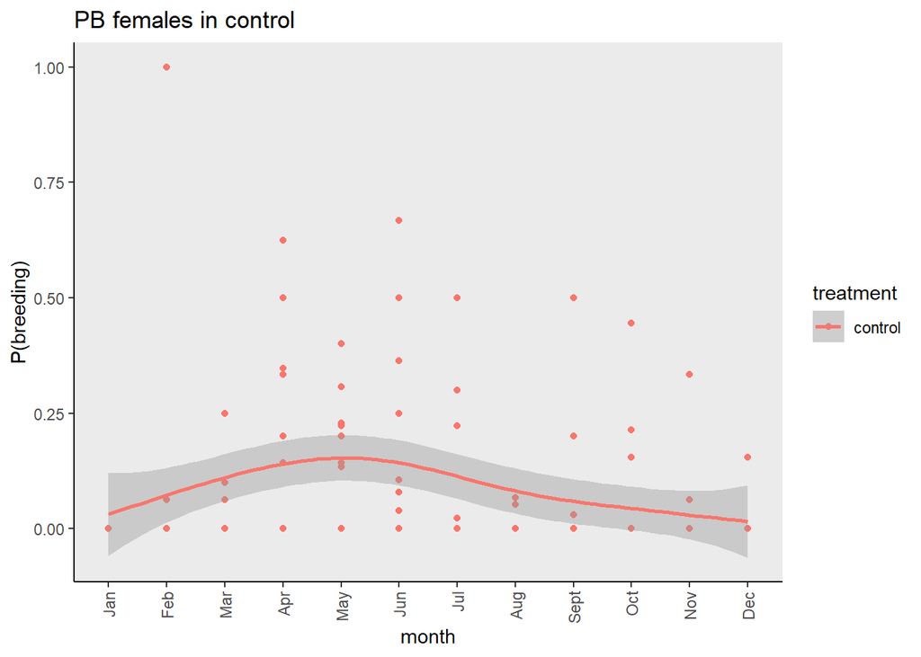

1. **M1 mod1**  
   This model draws from McLean and Guralnick’s paper (2020) where they built a separate GAM to reconstruct breeding phenology of PEMA and then make separate GLMMs to test for the relationship of breeding odds with breeding cues (i.e., photoperiod, temperature, precipitation). Not sure why they didn’t just make a single GAM and set the environmental variables as linear terms. Here, we use a logistic function and cubic cyclic regression spline smoothers (bs=“cc” because breeding events are cyclical).

```
##
## Family: binomial
## Link function: logit
##
## Formula:
## proportion ~ s(month, bs = "cc") + s(year) + ndvis_lag + temps_lag_mean +
##     ppts_lag_warm + ppts_lag_cool
##
## Parametric coefficients:
##                Estimate Std. Error z value Pr(>|z|)
## (Intercept)     -3.4859     0.3391 -10.281  < 2e-16 ***
## ndvis_lag        0.5408     0.1565   3.455  0.00055 ***
## temps_lag_mean   2.9567     1.1764   2.513  0.01196 *
## ppts_lag_warm    0.8171     0.2774   2.946  0.00322 **
## ppts_lag_cool   -0.7498     0.4710  -1.592  0.11139
## ---
## Signif. codes:  0 '***' 0.001 '**' 0.01 '*' 0.05 '.' 0.1 ' ' 1
##
## Approximate significance of smooth terms:
##            edf Ref.df Chi.sq  p-value
## s(month) 4.758  8.000  76.35  < 2e-16 ***
## s(year)  5.691  6.683  26.19 0.000386 ***
## ---
## Signif. codes:  0 '***' 0.001 '**' 0.01 '*' 0.05 '.' 0.1 ' ' 1
##
## R-sq.(adj) =  0.531   Deviance explained = 60.4%
## -REML = 117.96  Scale est. = 1         n = 133
```

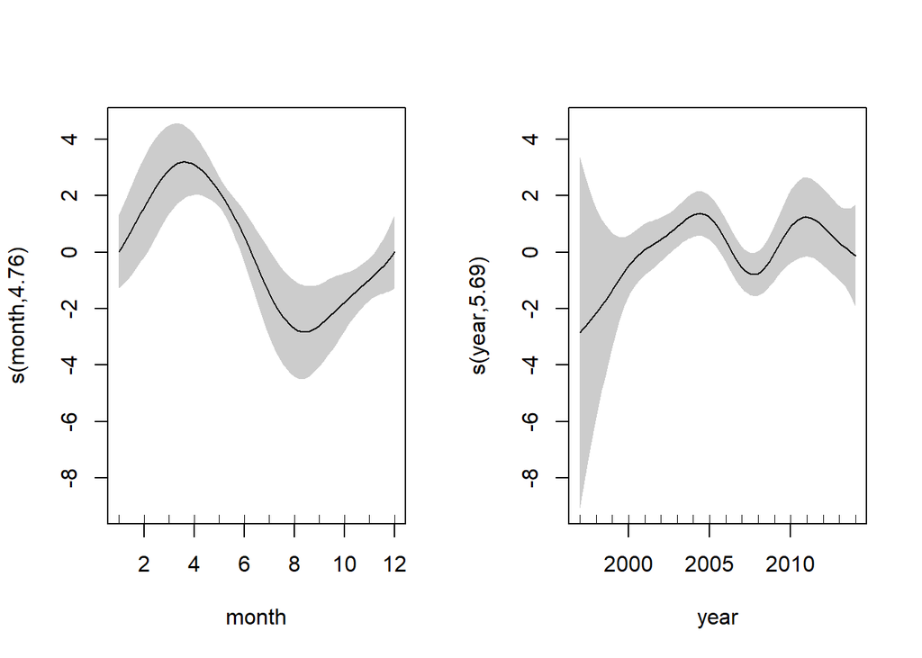

Fig.1. Partial effects plot (mod1)

```r
PB_female_con=pb_plot%>%filter(treatment=="control", sex=="female")
#no explicit biotic effects

mod1=mgcv::gam(proportion~s(month, bs="cc")+s(year)+ ndvis_lag+ temps_lag_mean+ppts_lag_warm+ppts_lag_cool, data=PB_female_con, method = 'REML', weights = abundance, family = binomial)
```

2. **M1 mod2**  
   This model is my attempt to make a simple spline model in Stan regardless of distribution (assumed to be normal). Here, I directly use the proportion data so not really weighting them properly. I am not really able to account for potential overdispersion and variation in the sample sizes (e.g., 1 reproductive in 2 total individuals is treated similarly as 2 reproductive in 4 individuals). Here, we use the “splines” package to create the B-splines with degree set at 3 (cubic cyclic) outside Stan and then add it as “data”. I could probably build the b-splines directly into Stan but this seems easier, and would make the model less complex. Plus, I still have other variables to add so making it less complex at this stage may be wise.

```r
X1 =PB_female_con$month
X2= PB_female_con$year
X3= PB_female_con$ndvis_lag
X4= PB_female_con$temps_lag_mean
X5= PB_female_con$ppts_lag_warm
X6= PB_female_con$ppts_lag_cool
num_data = length(X1)
B1 = t(bs(X1, df=NULL, knots=NULL, degree=3, intercept = FALSE)) # creating the B-splines for month, degree=3 for cubic spline
B2 = t(bs(X2, df=NULL, knots=NULL, degree=3, intercept = FALSE)) #creating B-splines for year
num_basis1 = nrow(B1)
num_basis2 = nrow(B2)
Y = PB_female_con$proportion

dat_list=list(X1 =PB_female_con$month,
              X2= PB_female_con$year,
              X3= PB_female_con$ndvis_lag,
              X4= PB_female_con$temps_lag_mean,
              X5= PB_female_con$ppts_lag_warm,
              X6= PB_female_con$ppts_lag_cool,
              num_data = length(X1),
              B1 = t(bs(X1, df=NULL, knots=NULL, degree=3, intercept = FALSE)),
              B2 = t(bs(X2, df=NULL, knots=NULL, degree=3, intercept = FALSE)),
              num_basis1 = nrow(B1),
              num_basis2 = nrow(B2),
              Y = PB_female_con$proportion)

mod2<-stan(model_code="
data {
  int num_data; //rows of observations
  int num_basis1; //no. of basis (order-1) for month
  int num_basis2; //no. of basis (order-1) for year
  real <lower=0,upper=1>Y[num_data]; //response variable (e.g., no.of breeding obs.)
  vector[num_data] X3; //lag_NDVI
  vector[num_data] X4; //lag_temp
  vector[num_data] X5;//lag warm precip
  vector[num_data] X6;//lag cool precip
  matrix[num_basis1, num_data] B1; //matrix of coefficients of splines(rows), length of X1 (columns)
   matrix[num_basis2, num_data] B2; //matrix of coefficients of splines(rows), length of X2 (columns)
}

parameters {
  row_vector[num_basis1] a_raw; // global smooth term for month
  row_vector[num_basis2] b_raw; // global smooth term for year
  real a0; //intercept
  real ndvi_eff;
  real temp_eff;
  real warm_ppt_eff;
  real cool_ppt_eff;

  real<lower=0> sigma; //error term
  real<lower=0> tau; // for noncentered parameterization of spline coefficients (month)
  real<lower=0> phi; // for noncentered parameterization of spline coefficients (year)

}

transformed parameters {
  row_vector[num_basis1] a; //coefficient for month smooth term
  row_vector[num_basis2] b; //coefficient for year smooth term

  vector[num_data] Y_hat;

  a = a_raw*tau;
  b = b_raw*phi;

 Y_hat=a0 + ndvi_eff*X3 +temp_eff*X4+ warm_ppt_eff*X5+ cool_ppt_eff*X6 + to_vector(a*B1)+ to_vector(b*B2);
 }

model {
  a_raw ~ normal(0, 1);
  b_raw ~ normal(0, 1);
  phi~normal(0,1);
  tau ~ normal(0, 1);
  sigma ~ normal(0, 1);
  ndvi_eff~normal(0,1);
  temp_eff~normal(0,1);
  warm_ppt_eff~normal(0,1);
  cool_ppt_eff~normal(0,1);
  Y~ normal(Y_hat, sigma);//likelihood
  }",iter=300,
data =dat_list, chains=2)
```

```
## Inference for Stan model: 01df2e89150fb59e794d42a09049453c.
## 2 chains, each with iter=300; warmup=150; thin=1;
## post-warmup draws per chain=150, total post-warmup draws=300.
##
##              mean se_mean   sd  2.5%   25%  50%  75% 97.5% n_eff Rhat
## a0           0.02    0.01 0.10 -0.17 -0.04 0.02 0.08  0.27    85 1.02
## ndvi_eff     0.03    0.00 0.02  0.00  0.01 0.03 0.04  0.05   121 1.02
## warm_ppt_eff 0.05    0.00 0.03 -0.01  0.03 0.05 0.07  0.11   360 1.00
## cool_ppt_eff 0.03    0.00 0.04 -0.05  0.01 0.04 0.06  0.10   234 1.00
## temp_eff     0.09    0.01 0.09 -0.05  0.03 0.08 0.14  0.34    44 1.07
##
## Samples were drawn using NUTS(diag_e) at Wed May 26 12:19:23 2021.
## For each parameter, n_eff is a crude measure of effective sample size,
## and Rhat is the potential scale reduction factor on split chains (at
## convergence, Rhat=1).
```

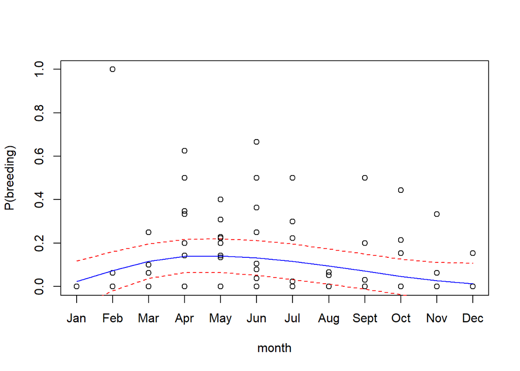

Fig.2a. spline fit over raw data (mod2)

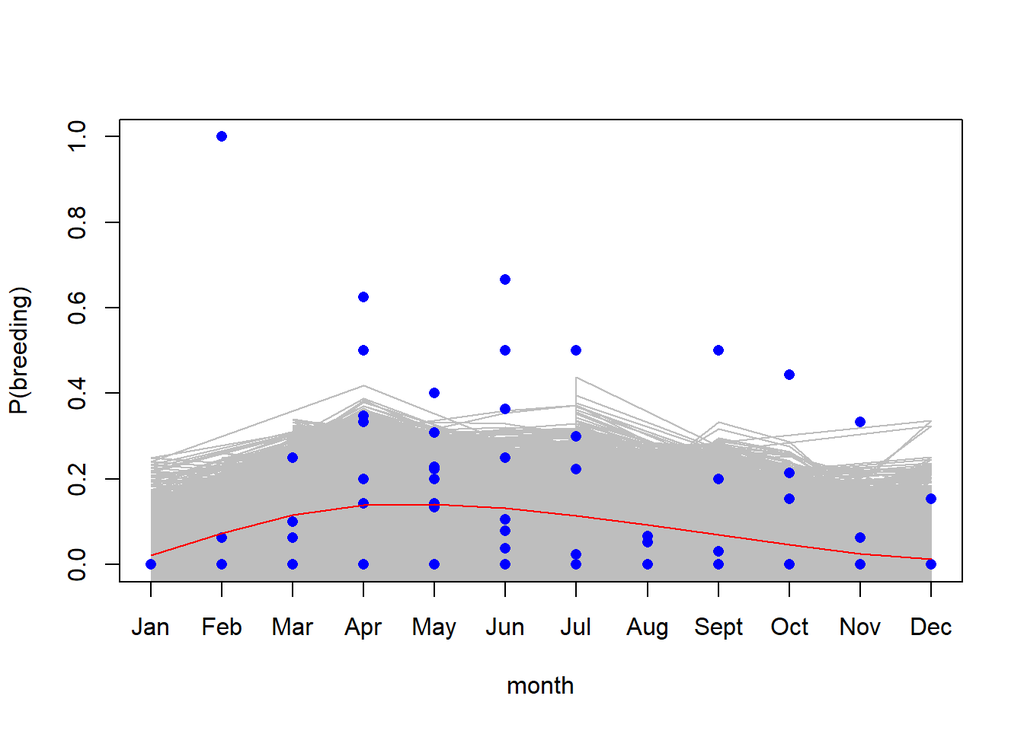

Fig.2b. posterior draws over raw data (mod2)

3. **M1 mod3**  
   This model has added complexity by assuming a beta-binomial (BB) distribution. This may be appropriate because if we use a binomial distribution, the probabilities are fixed for a certain number of trials (i.e., total indivs). But for BB model, the probabilities vary from trial to trial (which we may expect from month to month). This will help us account for the variation in sample sizes. Also, the BB model has an overdispersion term that may be appropriate especially for PPs that are less active/reproductive during winter, and will produce a lot of 0s.

*Note*: The sum of the linear terms will vary per level of complexity (if it is abiotic only, intra- or intra-and inter) but the sum of the linear terms will be the same all throughout with smoothed terms for month and year.

```r
X1= PB_female_con$month
X2= PB_female_con$year
X3= PB_female_con$ndvis_lag
X4= PB_female_con$temps_lag_mean
X5= PB_female_con$ppts_lag_warm
X6= PB_female_con$ppts_lag_cool
num_data= length(X1)
B1= t(bs(X1, df=NULL, knots=NULL, degree=3, intercept = FALSE))
B2= t(bs(X2, df=NULL, knots=NULL, degree=3, intercept = FALSE))
num_basis1= nrow(B1)
num_basis2= nrow(B2)
Y= PB_female_con$reproductive
n= PB_female_con$abundance

dat_list2=list(X1= PB_female_con$month,
               X2= PB_female_con$year,
               X3= PB_female_con$ndvis_lag,
               X4= PB_female_con$temps_lag_mean,
               X5= PB_female_con$ppts_lag_warm,
               X6= PB_female_con$ppts_lag_cool,
               num_data = length(X1),
               B1 = t(bs(X1, df=NULL, knots=NULL, degree=3, intercept = FALSE)),
               B2 = t(bs(X2, df=NULL, knots=NULL, degree=3, intercept = FALSE)),
               num_basis1 = nrow(B1),
               num_basis2 = nrow(B2),
               Y = PB_female_con$reproductive,
               n=PB_female_con$abundance)

mod3<-stan(model_code="
data {
  int num_data; //rows of observations
  int num_basis1; //no. of basis (order-1)
  int num_basis2; //no. of basis (order-1)

  int Y[num_data]; //response variable (# of reproductive)
  int n[num_data]; //total no.of indivs in plot

  vector[num_data] X3; //lag_NDVI
  vector[num_data] X4; //lag_temp
  vector[num_data] X5; //lag warm precip
  vector[num_data] X6;// lag cool precip

  matrix[num_basis1, num_data] B1; //matrix of coefficients of splines(rows), length of X1 (columns)
  matrix[num_basis2, num_data] B2; //matrix of coefficients of splines(rows), length of X2 (columns)

}

parameters {
 row_vector[num_basis1] a_raw; // smooth terms for month
  row_vector[num_basis2] b_raw; // smooth terms for year
  real a0; //intercept
  real ndvi_eff;
  real cool_ppt_eff;
  real temp_eff;
  real warm_ppt_eff;

  real<lower=0> sigma; //error term for shape params
  real<lower=0> tau; // for noncentered parameterization of spline coefficients (month)
 // real<lower=0> phi; // for noncentered parameterization of spline coefficients (year)

 vector <lower=0, upper=1> [num_data] pred_repro;//breeding odds as a parameter
}

transformed parameters {
  row_vector[num_basis1] a; //noncentered parameters of splines
  row_vector[num_basis2] b; //noncentered parameters of splines

  //beta dist of probability as a deterministic function
  vector <lower=0, upper=1> [num_data] Y_hat; // mean of response variable

 //beta shape params
  vector <lower=0> [num_data] a1;
  vector <lower=0> [num_data] b1;

  a = a_raw*tau;
  b = b_raw*tau;

  Y_hat = inv_logit(a0 + ndvi_eff*X3 +temp_eff*X4+ warm_ppt_eff*X5+ cool_ppt_eff*X6 + to_vector(a*B1)+ to_vector(b*B2));


a1=Y_hat*sigma;
b1=(1-Y_hat)*sigma;
}

model {
  a0~ normal(0,1);
  a_raw ~ normal(0, 1);
  b_raw ~ normal(0, 1);
  tau ~ normal(0, 1);
//  phi ~ normal(0, 1);
  sigma ~ normal(0, 1);
  ndvi_eff~normal(0,1);
  warm_ppt_eff~normal(0,1);
  cool_ppt_eff~normal(0,1);
  temp_eff~normal(0,1);
  pred_repro ~ beta(a1, b1);
  Y~ binomial(n, pred_repro);
}",
iter=2000, control=list(max_treedepth=12, adapt_delta=0.99),
data =dat_list2)
```

```
## Inference for Stan model: 6787201c5777ce8f0db4ee3cca93dd5a.
## 4 chains, each with iter=2000; warmup=1000; thin=1;
## post-warmup draws per chain=1000, total post-warmup draws=4000.
##
##               mean se_mean   sd  2.5%   25%   50%   75% 97.5% n_eff Rhat
## a0           -2.04    0.02 0.55 -3.16 -2.40 -2.05 -1.69 -0.94  1321 1.00
## ndvi_eff      0.16    0.01 0.18 -0.22  0.05  0.17  0.29  0.49   416 1.00
## warm_ppt_eff  0.54    0.01 0.29 -0.03  0.35  0.54  0.73  1.10  1047 1.00
## cool_ppt_eff -0.11    0.02 0.42 -0.95 -0.39 -0.11  0.17  0.69   761 1.01
## temp_eff      0.51    0.01 0.47 -0.39  0.21  0.49  0.81  1.48  1032 1.01
##
## Samples were drawn using NUTS(diag_e) at Wed May 26 12:23:29 2021.
## For each parameter, n_eff is a crude measure of effective sample size,
## and Rhat is the potential scale reduction factor on split chains (at
## convergence, Rhat=1).
```

*Notes:*  
* The intercept is still off. I’m not sure why. But the effect estimates for the different abiotic covariates now makes sense, negative for cool_precip, positive for NDVI, warm_precip and temperature. So, yay! There is high uncertainty in the spline fit (Fig.3a) though.And I’m not sure why the posterior draws look very erratic.

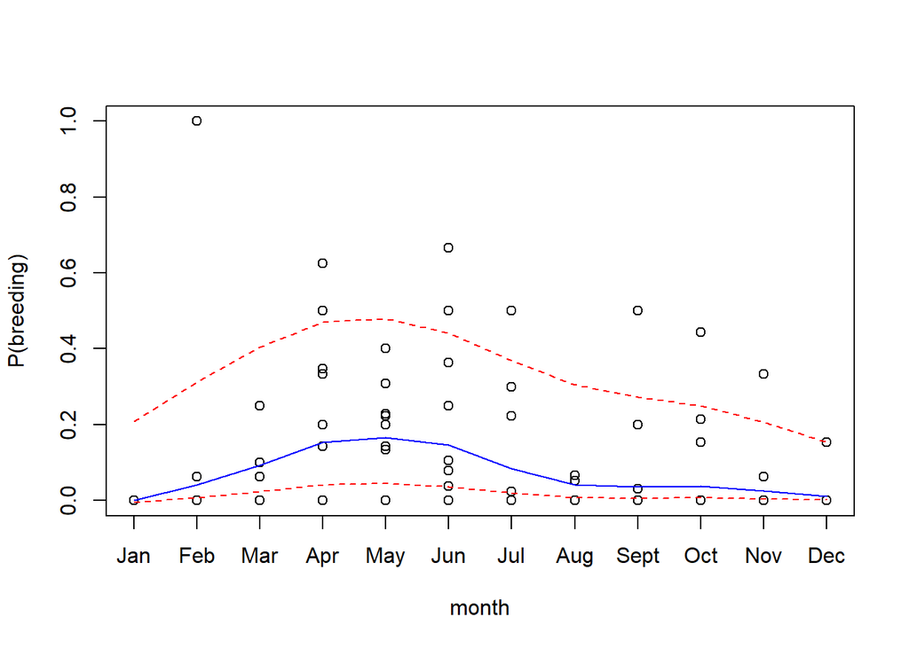

Fig.3a. spline fit over raw data (mod3)

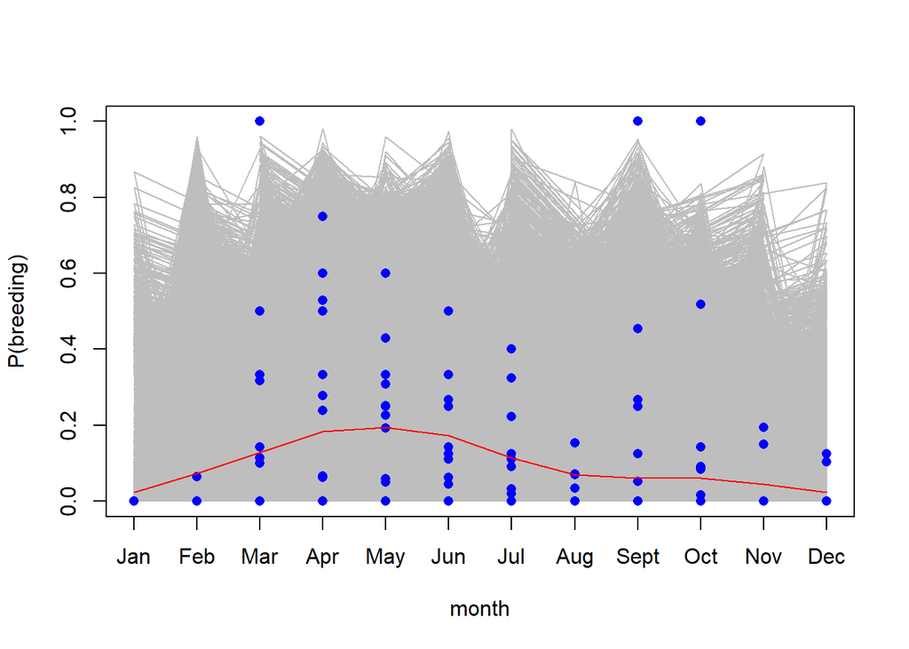